# Modelling Biotic Permeability

**Modelling Biotic Permeability using Interaction Niches**

Biotic permeability represents the balance between biotic potential, arising from positive interactions, and biotic resistance, resulting from negative interactions. Here we operationalize this concept with a trait-based approach that integrates species spatial occurrences, empirical interaction records, and trait data relevant to the focal interactions. We demonstrate the approach for hummingbird species in the Atlatic Forest based on their positive mutualistic interactions with plants (potential) and negative competitive interactions with co-occurring hummingbirds (resistance).

### 1. Environment setup and packages

Load the necessary libraries

```r
knitr::opts_chunk$set(echo = TRUE, warning = FALSE, message = FALSE)

rm(list = ls()) # Clean environment

# Set working directory
#setwd("")

# Required packages
library(ggplot2)
library(ks)
library(sf)
library(lattice)
library(gridExtra)
library(sjPlot)
library(terra)
library(rnaturalearth)
library(lwgeom)
library(ggpubr)
library(viridis)
library(gstat)
library(ggrepel)
library(tidyterra)
library(patchwork)
library(RColorBrewer)
```

### 2. Load, preprocess data and create helper functions

Align the nomenclature across interaction matrices, trait data (PCA), and spatial occurrences

```r
# Loading data
load("data/wide_interaction_matrix.RData") # interaction data
load('data/pcs_axes.RData') # PCA of plant traits
load("data/hummingbird_occurrences_spatial.RData") # hummingbird spatial occurrences
load("data/plant_occurrences_spatial.RData") # plant spatial occurrences

# Alignment and cleaning
pca_df <- data.frame(sp_faxes_coord_rcapacity)

colnames(species_plant_df) <- gsub("[ -]", "_", colnames(species_plant_df))
rownames(species_plant_df) <- gsub(" ", "_", rownames(species_plant_df))
names(occurrences_spatial) <- gsub(" ", "_", names(occurrences_spatial))
rownames(pca_df) <- gsub(" ", "_", rownames(pca_df))

# Match network and occurrences
network <- species_plant_df[names(species_plant_df) %in% names(occurrences_spatial_plants_final)]
humm_names <- rownames(network)
plant_names <- names(network)

occ_humm <- occurrences_spatial[,match(humm_names, names(occurrences_spatial))]
occ_plant <- occurrences_spatial_plants_final[,match(plant_names, names(occurrences_spatial_plants_final))]

# Spatial coordinates
cd <- data.frame(st_coordinates(st_centroid(occ_humm)))
occ_humm <- data.frame(occ_humm)[,-ncol(occ_humm)]
occ_plant <- data.frame(occ_plant)[,-ncol(occ_plant)]

# Load the shapefile of the Atlatic Forest from the IBGE
atl_lim <- st_read("data/biome_border/biome_border.shp")
atl_lim <- st_transform(atl_lim, crs = 4326)

# Load hummingbird shapefiles from BirdLife
range_maps_hb = st_read("data/hb_shapefile/Hummingbirds_filtered.shp")
```

Define some utility functions to help query the community structure and interaction partners

```r
get_com <- function(com, occ) as.numeric(occ[com,])
get_range <- function(spec, occ) occ[,spec]
get_plant_partners <- function(humm, network) as.numeric(network[humm,])
get_humm_partners <- function(plant, network) network[,plant]
```

### 3. Defining species interaction niches

First, we construct a multidimensional trait space based on traits mediating plant-hummingbird interactions. Next, we construct the interaction niche of each hummingbird species by projecting in this trait space only the plant species with documented interactions with the focal hummingbird. Interaction strength can be used to weight these plant species. A kernel density estimate (KDE) is then fitted to generate a continuous probability surface representing the species-specific interaction niche.

```r
kernel_list <- list() # Stores the KDE kernel for each bird species
kernel_eval <- list() # Stores the density estimates for all plants within each bird's kernel

for(k in 1:length(humm_names)){
  target_sp <- humm_names[k]

  # Identify plant partners for the current bird species
  partners <- colnames(species_plant_df)[species_plant_df[target_sp, ] > 0]
  subset <- which(row.names(pca_df) %in% partners)

  # Calculate Kernel Density Estimation (KDE) in functional space (PCA)
  kernel_list[[k]] <- kde(pca_df[subset, ])
  names(kernel_list[[k]]$cont) <- gsub('%', '', names(kernel_list[[k]]$cont))

  # Evaluate the bird's kernel at the position of ALL plants in the PCA space
  kernel_eval[[k]] <- kde(pca_df[subset, ], eval.points = pca_df)
}

names(kernel_list) <- humm_names
names(kernel_eval) <- humm_names
```

### 4. Computing Biotic Potential (BP) and Biotic Resistance (BR)

Biotic potential is quantified by projecting all plant species present in a grid cell into the focal hummingbird’s interaction niche and extracting their KDE-derived probability percentiles, which are then summed. These percentiles are interpreted as measures of how well each plant species matches the hummingbird’s interaction niche. Biotic resistance is quantified as the summed overlap in KDE values between the interaction niche of the focal hummingbird and those of all other hummingbird species co-occurring within the same cell.

```r
BP = BR = emp_crop = list()

humm_names_selected = c("Amazilia_lactea", "Aphantochroa_cirrochloris", "Chlorostilbon_lucidus", "Clytolaema_rubricauda")

# Bounding box coordinates
atl_xmin <- -55.33475; atl_xmax <- -28.84777
atl_ymin <- -29.98127; atl_ymax <- 0.9178872

for(h in 1:length(humm_names_selected)){
  target_sp <- humm_names_selected[h]
  emp <- get_range(target_sp, occ_humm)

  spatial_mask <- which(cd$X >= atl_xmin & cd$X <= atl_xmax &
                        cd$Y >= atl_ymin & cd$Y <= atl_ymax)

  cd_crop <- cd[spatial_mask, ]
  emp_crop[[h]] <- emp[spatial_mask]

  BP[[h]] <- rep(NA, length(emp_crop[[h]]))
  BR[[h]] <- rep(NA, length(emp_crop[[h]]))

  for(i in 1:length(emp_crop[[h]])){
    cell <- as.numeric(rownames(cd_crop[i, ]))
    humm_com <- get_com(cell, occ_humm)
    plant_com <- get_com(cell, occ_plant)

    if(sum(plant_com) > 0){
      local_plant_list <- plant_names[plant_com > 0]
      local_plant_pos <- which(rownames(pca_df) %in% local_plant_list)
      kernel_target <- kernel_list[[target_sp]]
      kernel_est <- kernel_eval[[target_sp]]

      # Interaction Probability (intP)
      intP <- sapply(kernel_est$estimate[local_plant_pos], function(x){
        as.numeric(names(kernel_target$cont[x >= kernel_target$cont])[1])
      }) / 100
      intP <- ifelse(is.na(intP), 0.001, intP)
      BP[[h]][i] <- sum(intP)
    } else {BP[[h]][i] <- 0}

    # Biotic Resistance (Competition)
    if(sum(humm_com) > 0){
      local_comp <- humm_names[which(humm_com > 0)]
      O <- rep(0, length(local_comp))
      for (k in 1:length(local_comp)){
        comp_sp <- local_comp[k]
        kernel_comp <- kernel_list[[comp_sp]]
        kernel_est_comp <- kernel_eval[[comp_sp]]
        intP_comp <- sapply(kernel_est_comp$estimate[local_plant_pos], function(x){
          as.numeric(names(kernel_comp$cont[x >= kernel_comp$cont])[1])
        }) / 100
        intP_comp <- ifelse(is.na(intP_comp), 0.001, intP_comp)
        O[k] <- sum(intP * intP_comp) / sum(intP^2)
        if(O[k] > 1) { O[k] <- 1 }
      }
    } else {O <- 0}
    BR[[h]][i] <- sum(O)
  }
}
names(emp_crop) = names(BP) = names(BR) = humm_names_selected
```

### 5. Computing Biotic Permeability

```r
a = 0.01
b = 0.05

Perm = list()
for(h in humm_names_selected){
  Perm[[h]] <- exp(-b * BR[[h]]) - exp(-a * BP[[h]])
}
```

### 6. Visualizing how biotic potential and resistance are estimated

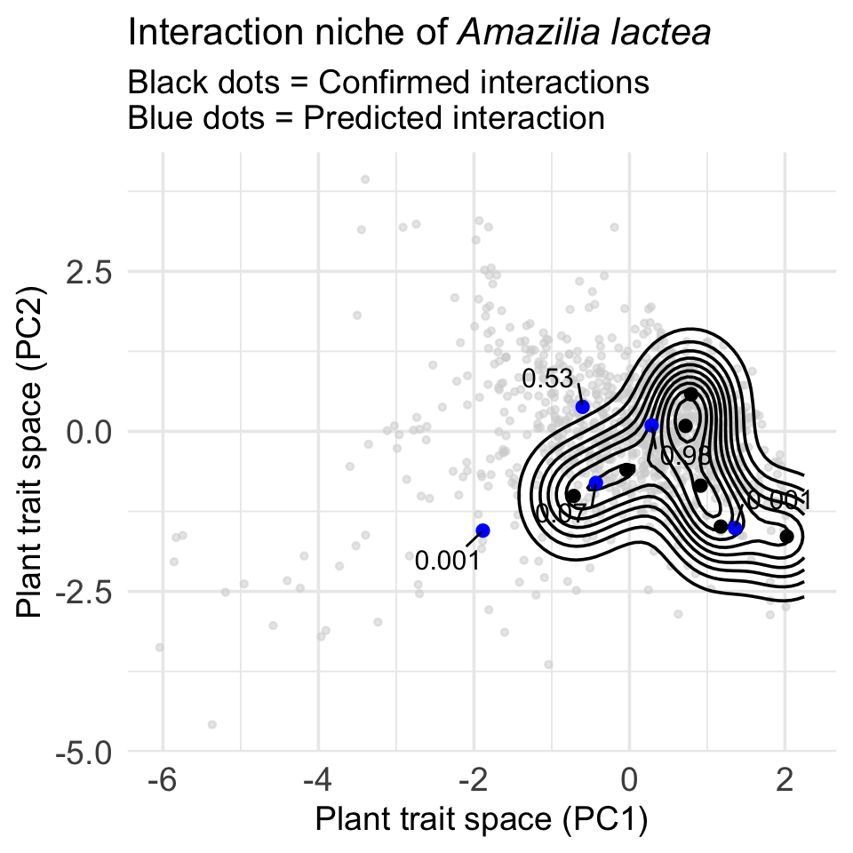

```r
target_sp <- "Amazilia_lactea"

# Subset the species present and their percentile
kernel_target <- kernel_list[[target_sp]]
kernel_est <- kernel_eval[[target_sp]]
names(kernel_target$cont) <- gsub('%','', names(kernel_target$cont))
intP <- sapply(kernel_est$estimate, function(x){as.numeric(names(kernel_target$cont[x >= kernel_target$cont])[1])})/100
intP <- ifelse(is.na(intP),0.001,intP)
plot.pca_subset <- data.frame(pca_df[subset,],intP[subset])
predict_partners <- sample(1:nrow(pca_df), 5) # Randomly choose potential partners for the plotting example
plot.pca_predicted <- data.frame(pca_df[predict_partners,],intP[predict_partners])

niche_plot <- ggplot(plot.pca_subset, aes(x = PC1, y = PC2)) +
  geom_point(data = pca_df, col = 'lightgray', alpha = 0.5, size = 1) +
  geom_point(col = 'black', size = 2) +
  geom_density_2d(col = 'black') +
  geom_point(data = plot.pca_predicted, col = 'blue', alpha = 1, size = 2) +
  geom_text_repel(data = plot.pca_predicted, aes(label = intP.predict_partners.), size = 4, box.padding = 0.5, max.overlaps = Inf) +
  labs(title = bquote("Interaction niche of" ~ italic(.(gsub("_", " ", target_sp)))),
    subtitle = "Black dots = Confirmed interactions\nBlue dots = Predicted interaction",
    x = "Plant trait space (PC1)", y = "Plant trait space (PC2)") +
  theme_minimal(base_size = 14) +
  theme(plot.title = element_text(size = 16, face = "bold"),
    plot.subtitle = element_text(size = 14),
    axis.title = element_text(size = 14),
    axis.text = element_text(size = 14))
print(niche_plot)
```

Here we compare the interaction niche of a target species against two potential competitors in the trait space.

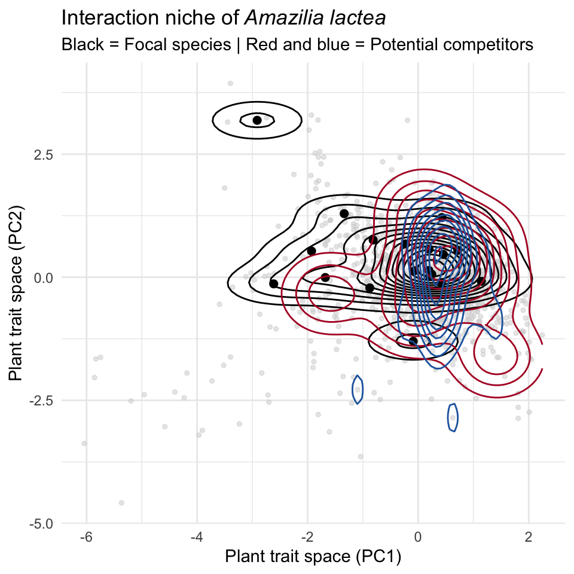

```r
competitor_sp1 <- humm_names_selected[2]
competitor_sp2 <- humm_names_selected[4]
partners <- colnames(species_plant_df)[species_plant_df[target_sp, ] > 0]
subset_idx <- which(row.names(pca_df) %in% partners)
plot.pca <- data.frame(pca_df[subset_idx, ])

ggplot(plot.pca, aes(x = PC1, y = PC2)) +
  geom_point(data = pca_df, col = 'lightgray', alpha = 0.5, size = 1) +
  geom_point(col = 'black', size = 2) +
  geom_density_2d(col = 'black') +
  geom_density_2d(data = as.data.frame(kernel_list[[competitor_sp1]]$x), col = '#B2182B') +
  geom_density_2d(data = as.data.frame(kernel_list[[competitor_sp2]]$x), col = '#2166AC') +
  labs(title = bquote("Interaction niche of" ~ italic(.(gsub("_", " ", target_sp)))),
    subtitle = "Black = Focal species | Red and blue = Potential competitors",
    x = "Plant trait space (PC1)",
    y = "Plant trait space (PC2)") +
  theme_minimal()
```

### 7. Mapping biotic resistance, biotic potential and biotic permeability for a species

```r
atl_v = terra::vect(atl_lim)
atl_geom = st_geometry(atl_lim)
br = ne_countries(country = "Brazil", returnclass = "sf")
br_v = terra::vect(br)

# Define the bounding box for plotting
bb <- st_bbox(c(xmin = -57, xmax = -26,
                ymin = -34, ymax = 0.5),
              crs = st_crs(range_maps_hb))


# Helper - interpolated raster
get_interp_raster <- function(x_coords, y_coords, values, mask_poly, res = 0.1) {
  df <- data.frame(x = x_coords, y = y_coords, z = values)
  e <- ext(range(x_coords), range(y_coords))
  r_base <- rast(e, resolution = res)
  gs_model <- gstat(formula = z ~ 1, locations = ~ x + y, data = df, nmax = 3, set = list(idp = 0))
  r_interp <- terra::interpolate(r_base, gs_model)[[1]]
  r_final <- terra::mask(r_interp, mask_poly)
  return(r_final)
}

# Helper - bivariate legend
make_bivariate_legend <- function(a = 0.01, b = 0.05) {
  legend_data <- expand.grid(
    BR = seq(0, 5, length.out = 100),
    BP = seq(0, 100, length.out = 100))

  legend_data$Perm <- exp(-b * legend_data$BR) - exp(-a * legend_data$BP)

  ggplot(legend_data, aes(x = BR, y = BP, fill = Perm)) +
    geom_raster() +
    scale_fill_viridis_c(option = "viridis") +
    scale_x_continuous(expand = c(0,0)) +
    scale_y_continuous(expand = c(0,0)) +
    theme_minimal() +
    labs(x = "Resistance", y = "Potential") +
    theme(
      aspect.ratio = 1,
      axis.title = element_text(size = 7),
      axis.text = element_blank(),
      axis.ticks = element_blank(),
      panel.grid = element_blank(),
      legend.position = "none",
      plot.background = element_rect(fill = "white", color = "black", linewidth = 0.5)
    )
}

plot_combined_panel <- function(h_idx, atl_v, br_v, range_maps, br_list, bp_list, cd_crop, bbox, a = 0.01, b = 0.05) {
  sp_name_raw <- h_idx
  sp_name_clean <- gsub("_", " ", sp_name_raw)

  # Filter range map and crop to bb
  hb_range <- range_maps[range_maps$sci_name == sp_name_clean, ]
  suppressWarnings({hb_range <- st_crop(hb_range, bbox)})

  # Generate interpolated rasters
  r_bp <- get_interp_raster(cd_crop$X, cd_crop$Y, bp_list[[sp_name_raw]], atl_v)
  r_br <- get_interp_raster(cd_crop$X, cd_crop$Y, br_list[[sp_name_raw]], atl_v)

  # Calculate bivariate raster
  r_perm <- exp(-b * r_br) - exp(-a * r_bp)
  names(r_perm) <- "Permeability"

  # Define common layers
  common_layers <- list(
    geom_sf(data = st_as_sf(atl_v), fill = NA, color = "black", linewidth = 0.3),
    geom_sf(data = st_as_sf(br_v), fill = NA, color = "black", linewidth = 0.3),
    geom_sf(data = hb_range, fill = NA, color = "#D55E00", linewidth = 0.8),
    coord_sf(xlim = c(bbox["xmin"], bbox["xmax"]),
             ylim = c(bbox["ymin"], bbox["ymax"]),
             expand = FALSE),
    theme_bw(), theme(axis.title = element_blank(), panel.grid = element_blank(),
      legend.position = "bottom", plot.title = element_text(size = 12, hjust = 0.5)))

  # Plot 1: Biotic Potential (BP)
  p_bp <- ggplot() +
    geom_spatraster(data = r_bp) +
    scale_fill_distiller(palette = "YlGn", direction = -1, name = "Potential", na.value = "white") +
    common_layers +
    labs(title = "Biotic Potential")

  # Plot 2: Biotic Resistance (BR)
  p_br <- ggplot() +
    geom_spatraster(data = r_br) +
    scale_fill_distiller(palette = "BuPu", direction = 1, name = "Resistance", na.value = "white") +
    common_layers +
    labs(title = "Biotic Resistance")

  # Plot 3: Bivariate map of Biotic Permeability
  p_biv_base <- ggplot() +
    geom_spatraster(data = r_perm) +
    scale_fill_viridis_c(option = "viridis", na.value = "white") +
    common_layers +
    labs(title = "Permeability") +
    theme(legend.position = "none")

  # Legend
  legend_inset <- make_bivariate_legend(a, b)
  p_biv_final <- p_biv_base +
    inset_element(legend_inset, left = 0.02, bottom = 0.60, right = 0.35, top = 0.98, align_to = 'panel')

  combined_plot <- (p_bp | p_br | p_biv_final) + plot_annotation(title = bquote(italic(.(sp_name_clean))),
      theme = theme(plot.title = element_text(size = 16, face = "bold", hjust = 0.5)))

  return(combined_plot)
}

final_fig <- plot_combined_panel(h_idx = target_sp,atl_v = atl_v, br_v = br_v, range_maps = range_maps_hb, br_list = BR, bp_list = BP, cd_crop = cd_crop, bbox = bb )
```

```
## [inverse distance weighted interpolation]
## [inverse distance weighted interpolation]
## [inverse distance weighted interpolation]
## [inverse distance weighted interpolation]
```

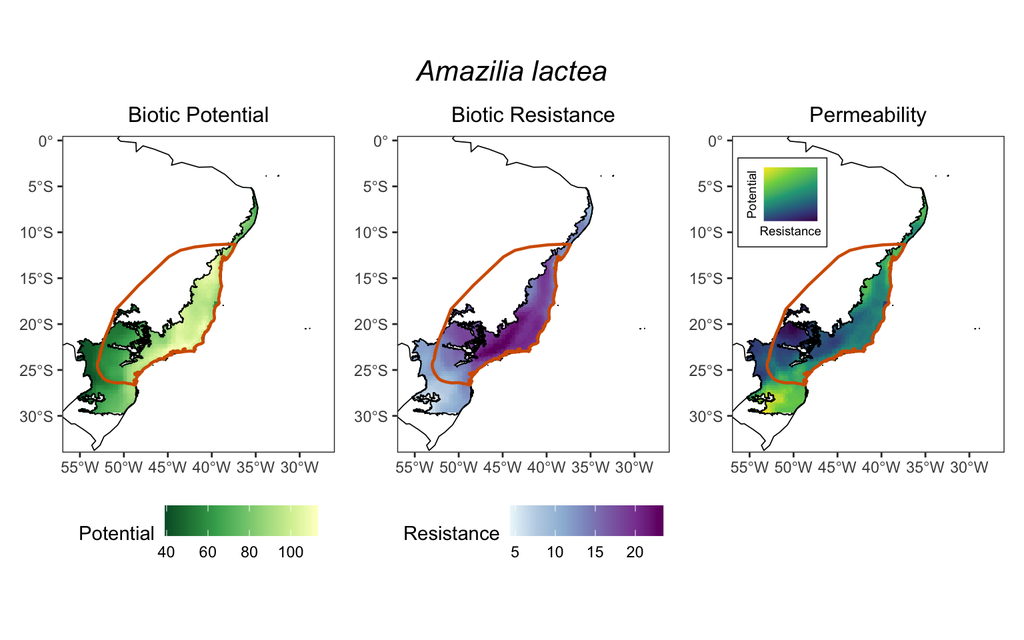

```r
final_fig
```